# Health At Fast Food Restaurants

# Arbys

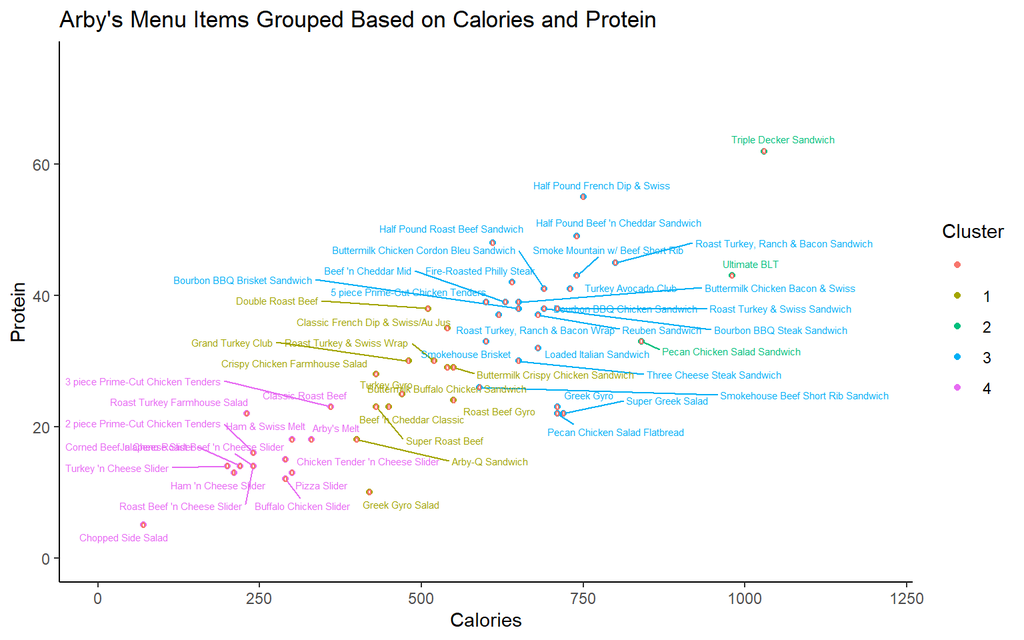

```
## # A tibble: 4 × 5
##   calories protein  size withinss cluster
##      <dbl>   <dbl> <int>    <dbl> <fct>
## 1     484.    26.3    13   35928. 1
## 2     950     46       3   19834  2
## 3     678.    37.3    24   71350. 3
## 4     259.    15.6    15   76085. 4
```

```
##   calories  protein
## 1 483.8462 26.30769
## 2 950.0000 46.00000
## 3 678.3333 37.29167
## 4 258.6667 15.60000
```

| Group 1 | Bring on the calories and protein! | Group 3 | If you’re on a diet . . . |
| --- | --- | --- | --- |
| Arby-Q Sandwich | Pecan Chicken Salad Sandwich | Beef ’n Cheddar Mid | Arby’s Melt |
| Beef ’n Cheddar Classic | Triple Decker Sandwich | Bourbon BBQ Brisket Sandwich | Classic Roast Beef |
| Buttermilk Buffalo Chicken Sandwich | Ultimate BLT | Bourbon BBQ Chicken Sandwich | Ham & Swiss Melt |
| Buttermilk Crispy Chicken Sandwich |  | Bourbon BBQ Steak Sandwich | 2 piece Prime-Cut Chicken Tenders |
| Classic French Dip & Swiss/Au Jus |  | Buttermilk Chicken Bacon & Swiss | 3 piece Prime-Cut Chicken Tenders |
| Double Roast Beef |  | Buttermilk Chicken Cordon Bleu Sandwich | Buffalo Chicken Slider |
| Grand Turkey Club |  | Fire-Roasted Philly Steak | Chicken Tender ’n Cheese Slider |
| Roast Beef Gyro |  | Greek Gyro | Corned Beef ’n Cheese Slider |
| Roast Turkey & Swiss Wrap |  | Half Pound Beef ’n Cheddar Sandwich | Ham ’n Cheese Slider |
| Super Roast Beef |  | Half Pound French Dip & Swiss | Jalapeno Roast Beef ’n Cheese Slider |
| Turkey Gyro |  | Half Pound Roast Beef Sandwich | Pizza Slider |
| Crispy Chicken Farmhouse Salad |  | Loaded Italian Sandwich | Roast Beef ’n Cheese Slider |
| Greek Gyro Salad |  | Pecan Chicken Salad Flatbread | Turkey ’n Cheese Slider |
|  |  | 5 piece Prime-Cut Chicken Tenders | Chopped Side Salad |
|  |  | Reuben Sandwich | Roast Turkey Farmhouse Salad |
|  |  | Roast Turkey & Swiss Sandwich |  |
|  |  | Roast Turkey, Ranch & Bacon Sandwich |  |
|  |  | Roast Turkey, Ranch & Bacon Wrap |  |
|  |  | Smoke Mountain w/ Beef Short Rib |  |
|  |  | Smokehouse Beef Short Rib Sandwich |  |
|  |  | Smokehouse Brisket |  |
|  |  | Three Cheese Steak Sandwich |  |
|  |  | Turkey Avocado Club |  |
|  |  | Super Greek Salad |  |

# Burger King

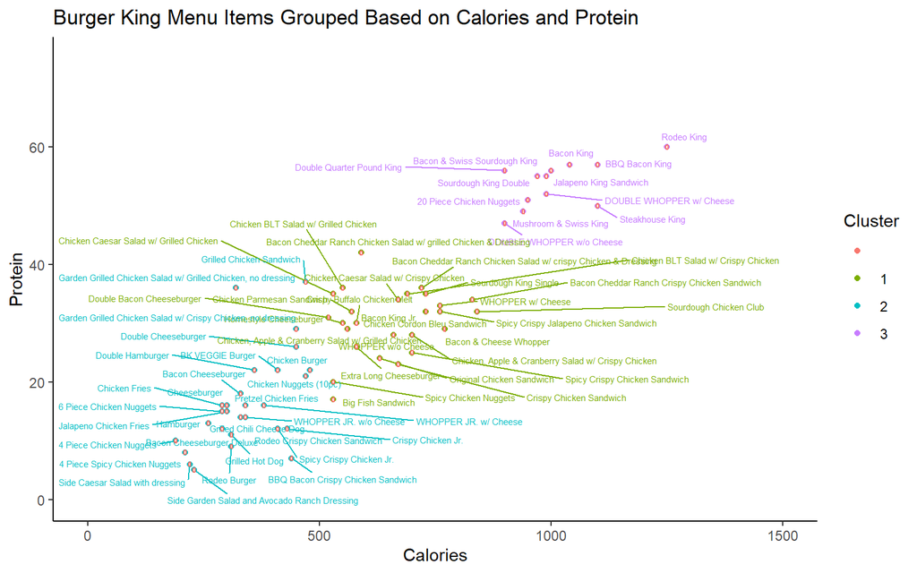

```
## # A tibble: 3 × 5
##   calories protein  size withinss cluster
##      <dbl>   <dbl> <int>    <dbl> <fct>
## 1     655.    30.4    27  247228. 1
## 2     346.    16.3    29  198721. 2
## 3    1052.    59.9    13  384342. 3
```

```
##    calories  protein
## 1  654.8148 30.37037
## 2  345.5172 16.27586
## 3 1052.3077 59.92308
```

```
## $`1`
##  [1] "Bacon King Jr"
##  [2] "Double Bacon Cheeseburger"
##  [3] "Extra Long Cheeseburger"
##  [4] "Homestyle Cheeseburger"
##  [5] "Sourdough King Single"
##  [6] "Bacon & Cheese Whopper"
##  [7] "WHOPPER w/o Cheese"
##  [8] "WHOPPER w/ Cheese"
##  [9] "Bacon Cheddar Ranch Chicken Salad w/ grilled Chicken & Dressing"
## [10] "Bacon Cheddar Ranch Chicken Salad w/ crispy Chicken & Dressing"
## [11] "Chicken BLT Salad w/ Grilled Chicken"
## [12] "Chicken BLT Salad w/ Crispy Chicken"
## [13] "Chicken Caesar Salad w/ Grilled Chicken"
## [14] "Chicken Caesar Salad w/ Crispy Chicken"
```

[output cut: 53 more lines]

# Chick-Fil-A

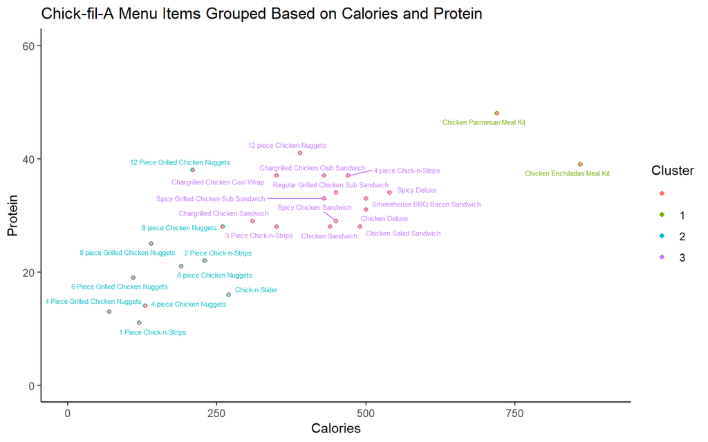

```
## # A tibble: 3 × 5
##   calories protein  size withinss cluster
##      <dbl>   <dbl> <int>    <dbl> <fct>
## 1     850     63.3     3   33801. 1
## 2     173     20.7    10   42806. 2
## 3     436.    32.8    14   56567. 3
```

```
##   calories  protein
## 1 850.0000 63.33333
## 2 173.0000 20.70000
## 3 435.7143 32.78571
```

```
## $`1`
## [1] "30 piece Chicken Nuggets"    "Chicken Enchiladas Meal Kit"
## [3] "Chicken Parmesan Meal Kit"
##
## $`2`
##  [1] "Chick-n-Slider"                   "1 Piece Chick-n-Strips"
##  [3] "2 Piece Chick-n-Strips"           "4 piece Chicken Nuggets"
##  [5] "6 piece Chicken Nuggets"          "8 piece Chicken Nuggets"
##  [7] "4 Piece Grilled Chicken Nuggets"  "6 Piece Grilled Chicken Nuggets"
##  [9] "8 piece Grilled Chicken Nuggets"  "12 Piece Grilled Chicken Nuggets"
##
## $`3`
##  [1] "Chargrilled Chicken Club Sandwich"
##  [2] "Chargrilled Chicken Sandwich"
##  [3] "3 Piece Chick-n-Strips"
##  [4] "4 piece Chick-n-Strips"
##  [5] "Chicken Deluxe"
##  [6] "12 piece Chicken Nuggets"
##  [7] "Chicken Salad Sandwich"
##  [8] "Chicken Sandwich"
##  [9] "Spicy Grilled Chicken Sub Sandwich"
## [10] "Regular Grilled Chicken Sub Sandwich"
## [11] "Smokehouse BBQ Bacon Sandwich"
## [12] "Spicy Chicken Sandwich"
## [13] "Spicy Deluxe"
## [14] "Chargrilled Chicken Cool Wrap"
```

# Dairy Queen

## Calories vs Protein

### Graph of Clusters

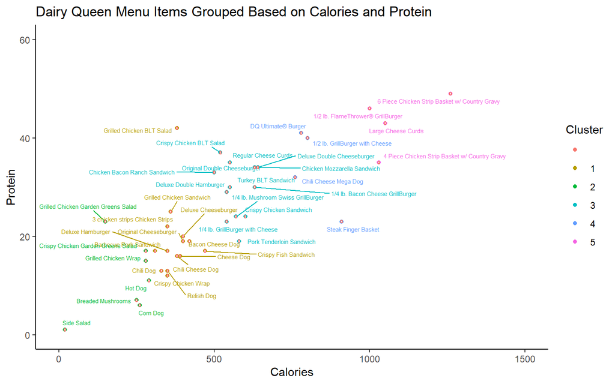

### Information About Clusters

| calories | protein | size | withinss | cluster |
| --- | --- | --- | --- | --- |
| 374.2857 | 19.14286 | 14 | 22268.57 | 1 |
| 218.5714 | 11.42857 | 7 | 59821.43 | 2 |
| 576.1538 | 29.69231 | 13 | 27880.46 | 3 |
| 812.5000 | 34.00000 | 4 | 13685.00 | 4 |
| 1085.0000 | 43.25000 | 4 | 42208.75 | 5 |

# Mcdonalds

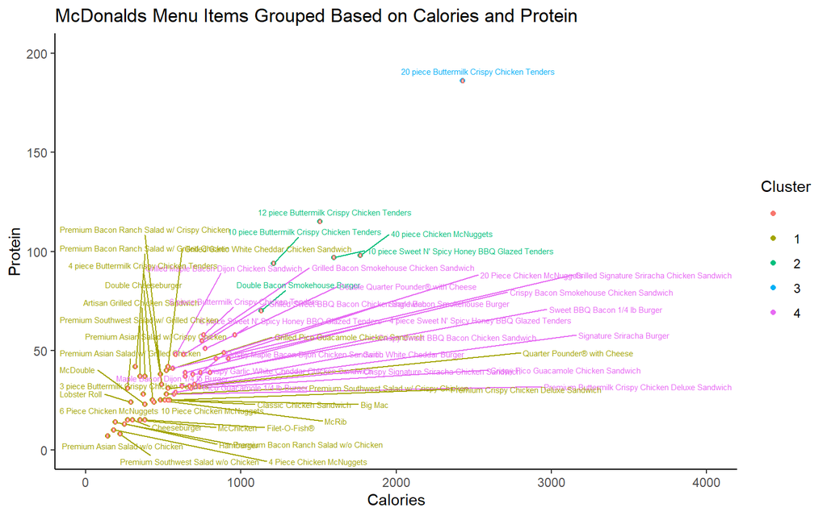

```
## # A tibble: 4 × 5
##   calories protein  size withinss cluster
##      <dbl>   <dbl> <int>    <dbl> <fct>
## 1     384.    25.1    29  422469. 1
## 2    1444     94.8     5  289359. 2
## 3    2430    186       1       0  3
## 4     715.    41.3    22  277586. 4
```

```
##    calories   protein
## 1  383.7931  25.10345
## 2 1444.0000  94.80000
## 3 2430.0000 186.00000
## 4  714.5455  41.31818
```

```
## $`1`
##  [1] "Artisan Grilled Chicken Sandwich"
##  [2] "Big Mac"
##  [3] "Cheeseburger"
##  [4] "Classic Chicken Sandwich"
##  [5] "Double Cheeseburger"
##  [6] "Filet-O-Fish®"
##  [7] "Grilled Garlic White Cheddar Chicken Sandwich"
##  [8] "Hamburger"
##  [9] "Lobster Roll"
## [10] "McChicken"
## [11] "McDouble"
## [12] "McRib"
## [13] "Grilled Pico Guacamole Chicken Sandwich"
## [14] "Premium Crispy Chicken Deluxe Sandwich"
```

[output cut: 49 more lines]

# Sonic

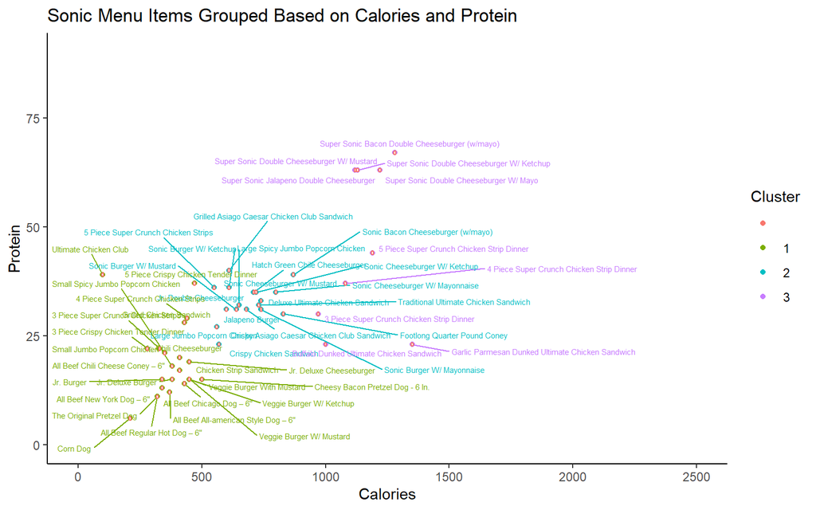

```
## # A tibble: 3 × 5
##   calories protein  size withinss cluster
##      <dbl>   <dbl> <int>    <dbl> <fct>
## 1     378.    18.7    24  189883. 1
## 2     682.    32.8    19  150001. 2
## 3    1146     47.6    10  128210. 3
```

```
##    calories  protein
## 1  377.5000 18.66667
## 2  682.1053 32.78947
## 3 1146.0000 47.60000
```

```
## $`1`
##  [1] "Jr. Burger"
##  [2] "Jr. Chili Cheeseburger"
##  [3] "Jr. Deluxe Burger"
##  [4] "Jr. Deluxe Cheeseburger"
##  [5] "Veggie Burger W/ Ketchup"
##  [6] "Veggie Burger With Mustard"
##  [7] "Veggie Burger W/ Mustard"
##  [8] "Grilled Chicken Sandwich"
##  [9] "Chicken Strip Sandwich"
## [10] "3 Piece Crispy Chicken Tender Dinner"
## [11] "5 Piece Crispy Chicken Tender Dinner"
## [12] "Small Jumbo Popcorn Chicken"
## [13] "Small Spicy Jumbo Popcorn Chicken"
## [14] "3 Piece Super Crunch Chicken Strips"
```

[output cut: 43 more lines]

# References

Typically, references in R Markdown (and LaTeX) files are [incorporated with a BibTeX database](https://bookdown.org/yihui/rmarkdown-cookbook/bibliography.html) (a .bib file). You can try this approach or manually include either a numbered or alphabetized list.

Columbia University has compiled some guidance on [how to cite data](https://guides.library.columbia.edu/datacitation). Some data sources will give you the citation information to copy and paste. Use the provided citations or citation styles in those cases.

You can list R package citations with the code `citation("packageName")` in the console and then copy (and reformat as needed) the relevant text, e.g.,

```
##
##
##   Xie Y, Cheng J, Tan X (2023). _DT: A Wrapper of the JavaScript
##   Library 'DataTables'_. R package version 0.27,
##   <https://CRAN.R-project.org/package=DT>.
##
## A BibTeX entry for LaTeX users is
##
##   @Manual{,
##     title = {DT: A Wrapper of the JavaScript Library 'DataTables'},
##     author = {Yihui Xie and Joe Cheng and Xianying Tan},
##     year = {2023},
##     note = {R package version 0.27},
##     url = {https://CRAN.R-project.org/package=DT},
##   }
```

The following citations are based on the American Statistical Association citation style (not all of these references are used in this document).:

Baumer, B. S., Kaplan, D. T., and Horton, N. J. (2021), *Modern Data Science with R* (2nd ed.), Boca Raton, FL: CRC Press.

Broman, K. W. and Woo, K. H. (2018), “Data Organization in Spreadsheets,” *The American Statistician*, 72:1, 2-10, doi: 10.1080/00031305.2017.1375989

Columbia University Libraries (n.d.), “Data Citation,” available at https://guides.library.columbia.edu/datacitation.

McNamara, A. and Horton N. J. (2018) “Wrangling Categorical Data in R,” *The American Statistician*, 72:1, 97-104, doi: 10.1080/00031305.2017.1356375.

Shah, Syed A. A. (October 2022), “Starbucks Drinks” (Version 1), *Kaggle*, available at https://www.kaggle.com/datasets/syedasimalishah/starbucks-drinks.